# More Basics

Lauren Talluto

15.01.2024

# More data manipulation

- Here we have a sample of abundances of 5 different tree species in plots across a number of years:
- Note that the format of the data makes some analyses easy
  - What is the average abundance for *Abies balsamifera* across all years?
- But other things are harder
  - What is the average of all species combined for each year?
  - What is the average for each species among years?

Today we will look at three useful functions for manipulating data frames in more complicated/interesting cases.

```r
trees = read.csv("data/tree_abundance.csv")
```

```r
head(trees)
```

```
##   pid year Abies.balsamifera Acer.saccharum Betula.papyrifera
## 1   1 1980                 4              0                 0
## 2   2 2006                40              0                 1
## 3   3 2006                36              0                 9
## 4   4 1980                 3              0                 0
## 5   5 1980                 4              0                 0
## 6   6 1980                16              0                 0
##   Populus.tremuloides Tsuga.canadensis
## 1                   0                0
## 2                   0                0
## 3                   0                0
## 4                   0                0
## 5                   0                0
## 6                   0                0
```

# More data manipulation: tall vs. wide data

- Recall that the columns of our data frame should each be a single variable. This dataset violates this pinciple!
  - One varaible, `abundance`, is spread across five colums.
  - Another variable, `species` is not encoded in a column at all! Rather, the information in this variable is encoded in the *column names*
- We can say that this dataset is in a **wide** format

```r
head(trees)
```

```
##   pid year Abies.balsamifera Acer.saccharum Betula.papyrifera
## 1   1 1980                 4              0                 0
## 2   2 2006                40              0                 1
## 3   3 2006                36              0                 9
## 4   4 1980                 3              0                 0
## 5   5 1980                 4              0                 0
## 6   6 1980                16              0                 0
##   Populus.tremuloides Tsuga.canadensis
## 1                   0                0
## 2                   0                0
## 3                   0                0
## 4                   0                0
## 5                   0                0
## 6                   0                0
```

# More data manipulation: tall vs. wide data

- Recall that the columns of our data frame should each be a single variable. This dataset violates this pinciple!
  - One varaible, `abundance`, is spread across five colums.
  - Another variable, `species` is not encoded in a column at all! Rather, the information in this variable is encoded in the *column names*
- We can say that this dataset is in a **wide** format
- An add-on package, `reshape2`, can help us convert between **wide** and **tall** data frames with two functions:
1. From wide => tall: `melt`
2. From tall => wide: `dcast`

```r
# install.packages("reshape2") # run this once, to install the package
library("reshape2")
trees_tall = melt(trees, id.vars = c("pid", "year"),
                  variable.name = "species",
                  value.name = "abundance")
head(trees_tall)
```

```
##   pid year           species abundance
## 1   1 1980 Abies.balsamifera         4
## 2   2 2006 Abies.balsamifera        40
## 3   3 2006 Abies.balsamifera        36
## 4   4 1980 Abies.balsamifera         3
## 5   5 1980 Abies.balsamifera         4
## 6   6 1980 Abies.balsamifera        16
```

# More data manipulation: tall vs. wide data

- Tall-format data are generally easier to work with (sometimes this is called “tidy” data in the R world)
- **Recommendation** - keep your data tall, convert to wide as needed using `dcast`

```r
# install.packages("reshape2") # run this once, to install the package
library("reshape2")
trees_tall = melt(trees, id.vars = c("pid", "year"),
                  variable.name = "species",
                  value.name = "abundance")
head(trees_tall)
```

```
##   pid year           species abundance
## 1   1 1980 Abies.balsamifera         4
## 2   2 2006 Abies.balsamifera        40
## 3   3 2006 Abies.balsamifera        36
## 4   4 1980 Abies.balsamifera         3
## 5   5 1980 Abies.balsamifera         4
## 6   6 1980 Abies.balsamifera        16
```

# More data manipulation: tall vs. wide data

- If our data are tall, we can easily perform all kinds of operations.
- Here we cast the data to be wide again, but this time broadcasting both the `species` and `year` variables into columns and filling in zeros

```r
trees_wide = dcast(trees_tall, pid ~ species + year,
                   value.var = "abundance", fill = 0)
trees_wide[1:10, 1:5]
```

```
##    pid Abies.balsamifera_1975 Abies.balsamifera_1980 Abies.balsamifera_1985
## 1    1                      0                      4                      0
## 2    2                      0                      0                      0
## 3    3                      0                      0                      0
## 4    4                      0                      3                      0
## 5    5                      0                      4                      0
## 6    6                      0                     16                      0
## 7    7                      0                      0                      0
## 8    8                      0                      4                      0
## 9    9                      0                     30                      0
## 10  10                      0                      0                      0
##    Abies.balsamifera_1988
## 1                       0
## 2                       0
## 3                       0
## 4                       0
## 5                       0
## 6                       0
## 7                       0
## 8                       0
## 9                       0
## 10                      0
```

# Taking subsets

- If our data are tall, we can easily perform all kinds of operations.
- `subset` gives you a new data frame that is a subset of the old one

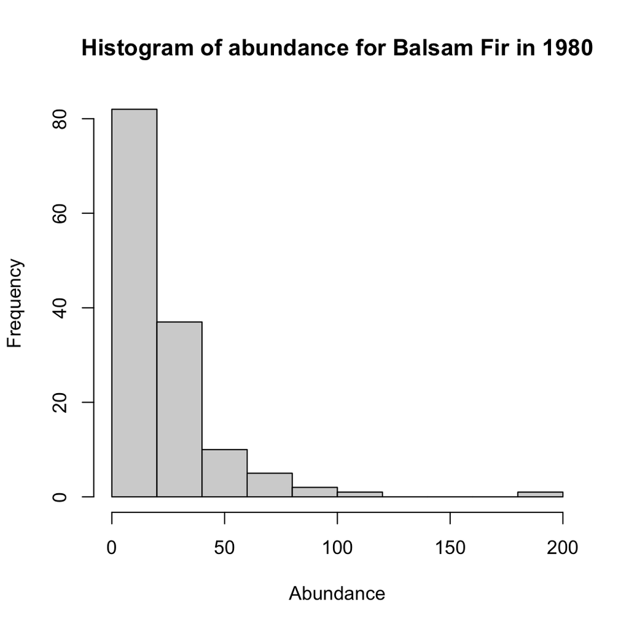

```r
balsam_fir_1980 = subset(trees_tall,
                         species == "Abies.balsamifera" &
                            year == 1980)
head(balsam_fir_1980)
```

```
##   pid year           species abundance
## 1   1 1980 Abies.balsamifera         4
## 4   4 1980 Abies.balsamifera         3
## 5   5 1980 Abies.balsamifera         4
## 6   6 1980 Abies.balsamifera        16
## 7   7 1980 Abies.balsamifera         0
## 8   8 1980 Abies.balsamifera         4
```

# Boxplots on tall data

- If our data are tall, we can easily perform all kinds of operations.
- Boxplots can use a simple formula syntax

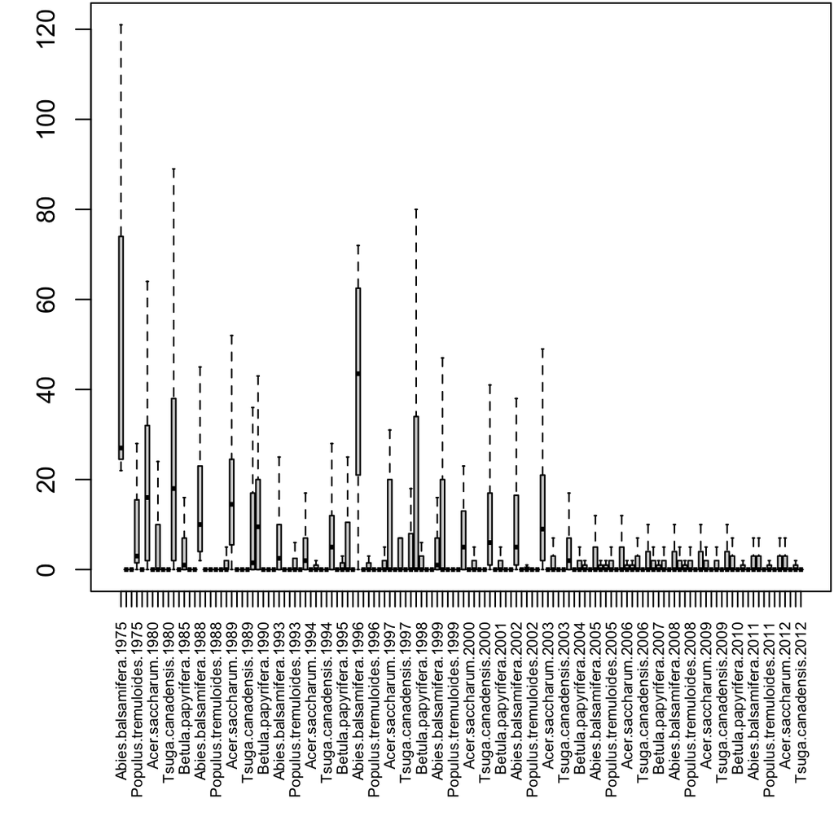

```r
par(mar = c(8, 3, 0.1, 0.1)) # adjust the margins
# draw a boxplot of abundace, grouped by species and year
bpl = boxplot(abundance ~ species + year,
            # outline = FALSE disables ploting outliers
              data = trees_tall, outline = FALSE,
            # xlab disables the x-axis label, xaxt = "n" disables the x-axis
              xlab = "", xaxt = "n")

# Here we draw a custom x-axis with labels rotated 90 degrees
axis(side = 1, at = 1:length(bpl$names),
     labels = bpl$names, cex.axis = 0.6, las = 2)
```

# Aggregation

- We can use `aggregate` to compute all kinds of summaries
  - A bit like a supercharged `tapply`

```r
# compute the mean of abundance, grouped by species and year
head(aggregate(abundance ~ species + year,
               data = trees_tall, FUN = mean))
```

```
##               species year abundance
## 1   Abies.balsamifera 1975      56.7
## 2      Acer.saccharum 1975       0.0
## 3   Betula.papyrifera 1975       0.0
## 4 Populus.tremuloides 1975      10.3
## 5    Tsuga.canadensis 1975       0.0
## 6   Abies.balsamifera 1980      21.8
```

# Paired (x,y) datasets

- We often measure multiple variables about the same **experimental unit**
- For example: each penguin has bill length and depth, flipper length, and body mass
- For the simplest case, we can consider how two of these variables, `flipper_length_mm` and `body_mass_g`, relate to one another

```r
# load penguin data
data(penguins, package = "palmerpenguins")
# convert to a data frame
penguins = as.data.frame(penguins)
# remove NAs
penguins = penguins[complete.cases(penguins),]
head(penguins)
```

```
##   species    island bill_length_mm bill_depth_mm flipper_length_mm body_mass_g
## 1  Adelie Torgersen           39.1          18.7               181        3750
## 2  Adelie Torgersen           39.5          17.4               186        3800
## 3  Adelie Torgersen           40.3          18.0               195        3250
## 5  Adelie Torgersen           36.7          19.3               193        3450
## 6  Adelie Torgersen           39.3          20.6               190        3650
## 7  Adelie Torgersen           38.9          17.8               181        3625
##      sex year
## 1   male 2007
## 2 female 2007
## 3 female 2007
## 5 female 2007
## 6   male 2007
## 7 female 2007
```

# Scatterplots for paired data

- We use **scatterplots** to examine paired variables like this
- In R, this is done with the `plot` function.
- Here we see there is strong dependence between the two variables

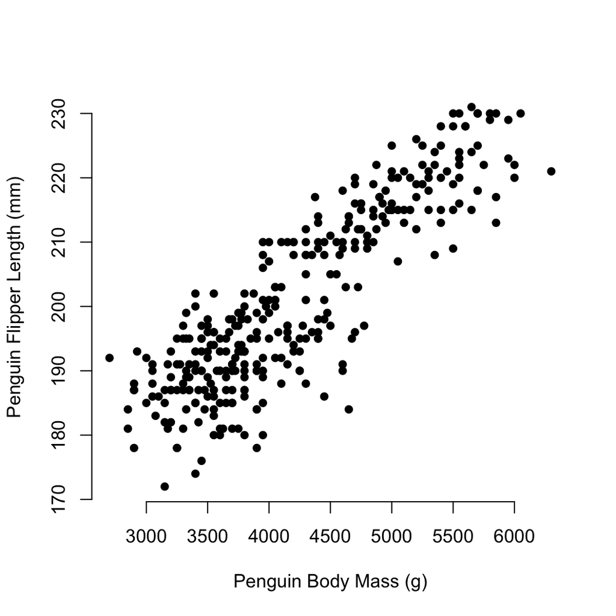

```r
# pch: plotting character, the symbol to use for the dots
# bty: the type of box to draw around the plot, 'n' disables this
plot(flipper_length_mm ~ body_mass_g, data = penguins, pch = 16, bty = 'n',
     xlab = "Penguin Body Mass (g)", ylab = "Penguin Flipper Length (mm)")
```

# Scatterplots for paired data

- We use **scatterplots** to examine paired variables like this
- In R, this is done with the `plot` function.
- Here we see there is strong dependence between the two variables
- If we use `ggplot`, we can also vary colours by categories (e.g., species)

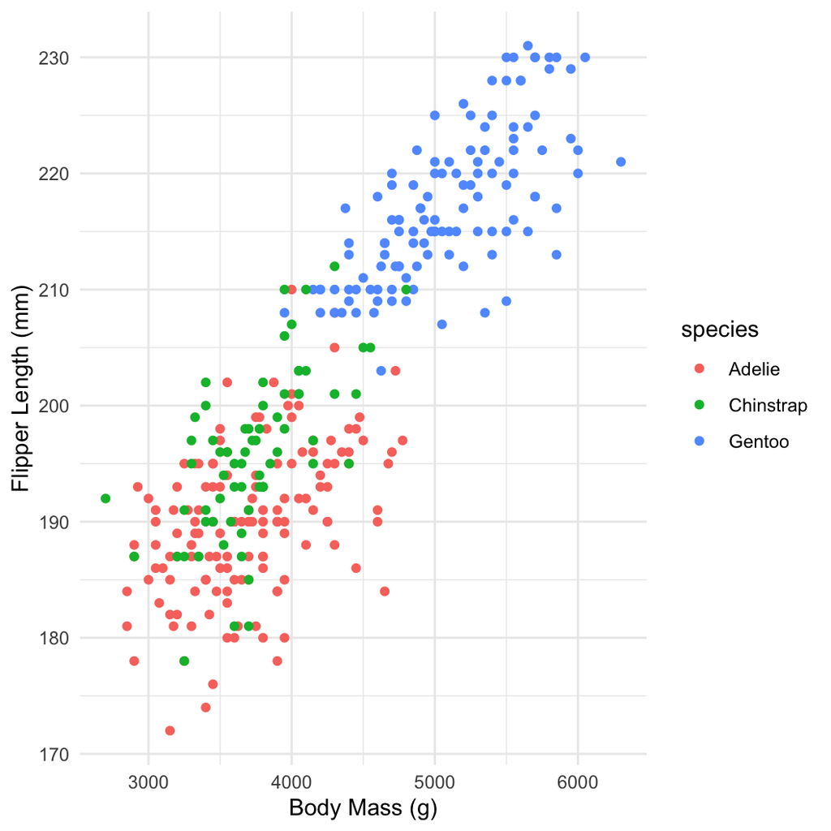

```r
ggplot(penguins) +
    geom_point(aes(x = body_mass_g, y = flipper_length_mm,
                   colour = species)) +
    theme_minimal() +
    xlab("Body Mass (g)") + ylab("Flipper Length (mm)")
```

# Covariance

- If two variables $x$ and $y$ are (**independent**), we can say that if $x$ is known, we have no additional information about $y$ (and vice-versa).
- In other words, the distribution of values of y does not change with respect to x.

$$pr(y|x) = pr(y)$$

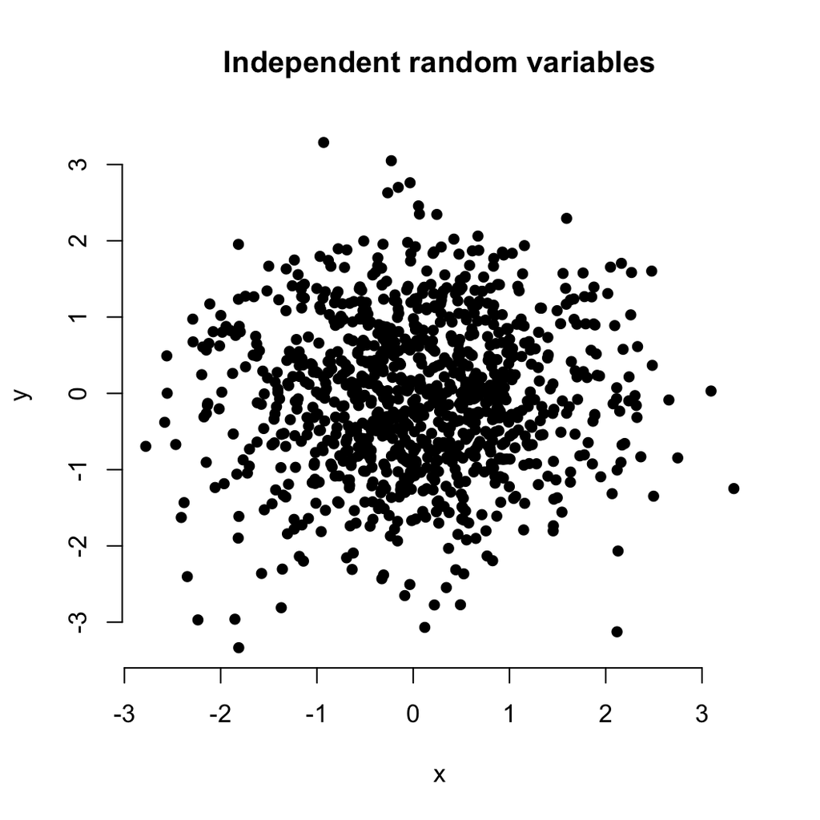

```r
x = rnorm(1000)
y = rnorm(1000) # these variables are independent

plot(x, y, pch=16, bty='n', main = "Independent random variables")
```

# Covariance

- Two variables that **covary** do not have this independence property; the values in $x$ can be used to predict $y$ (with some error), and vice-versa.
- The **sample covariance** ($\mathrm{cov}_{xy}$) looks similar to the equation for the sample variance, but relates to the amount of variation that is shared between $x$ and $y$

$$\mathrm{cov}_{xy} = \frac{\sum_{i=1}^n \left (x_i - \bar{x} \right)
\left(y_i - \bar{y} \right)}{n-1}$$

```r
# in R:
c(cov(x1, y1),
  cov(x2, y2),
  cov(x3, y3))
```

```
## [1]  0.80012 -0.41042 -0.00761
```

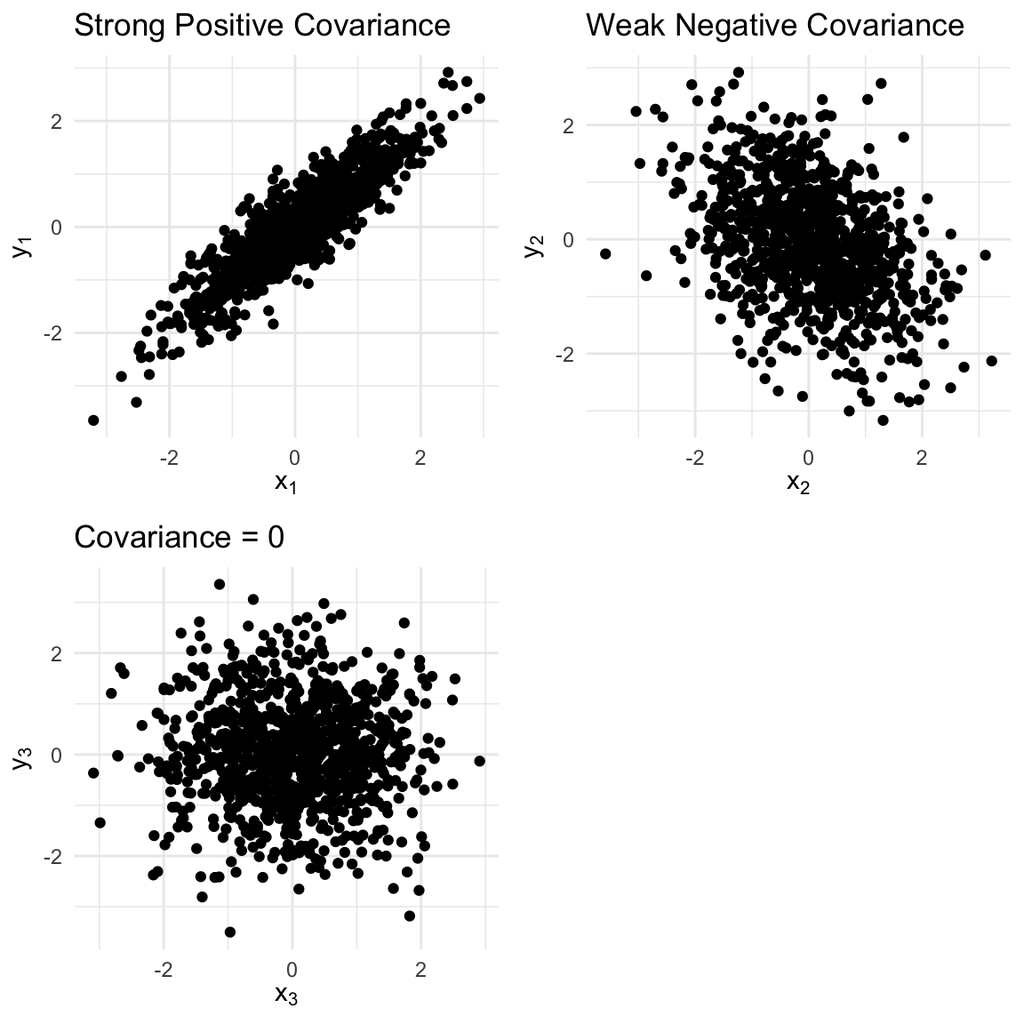

# Correlation

- Like with the mean and standard deviation, we can **rescale** the covariance to make it easier to compare different datasets.
- Scale-independent covariance is called **correlation**; for many datasets we use the **Pearson correlation coefficient** $\rho_{xy}$.
- Ranges from $-1$ to $1$. Zero means zero covariance. $-1$ and $1$ indicates that $x$ and $y$ predict each other perfectly!

$$\begin{aligned}
\mathrm{cov}_{xy} & = \frac{\sum_{i=1}^n \left (x_i - \bar{x}
\right) \left(y_i - \bar{y} \right)}{n-1} \\
r_{xy} & = \frac{\mathrm{cov}_{xy}}{s_x s_y}
\end{aligned}$$

```r
# in R:
c(cor(x1, y1),
  cor(x2, y2),
  cor(x3, y3))
```

```
## [1]  0.89570 -0.39786 -0.00738
```

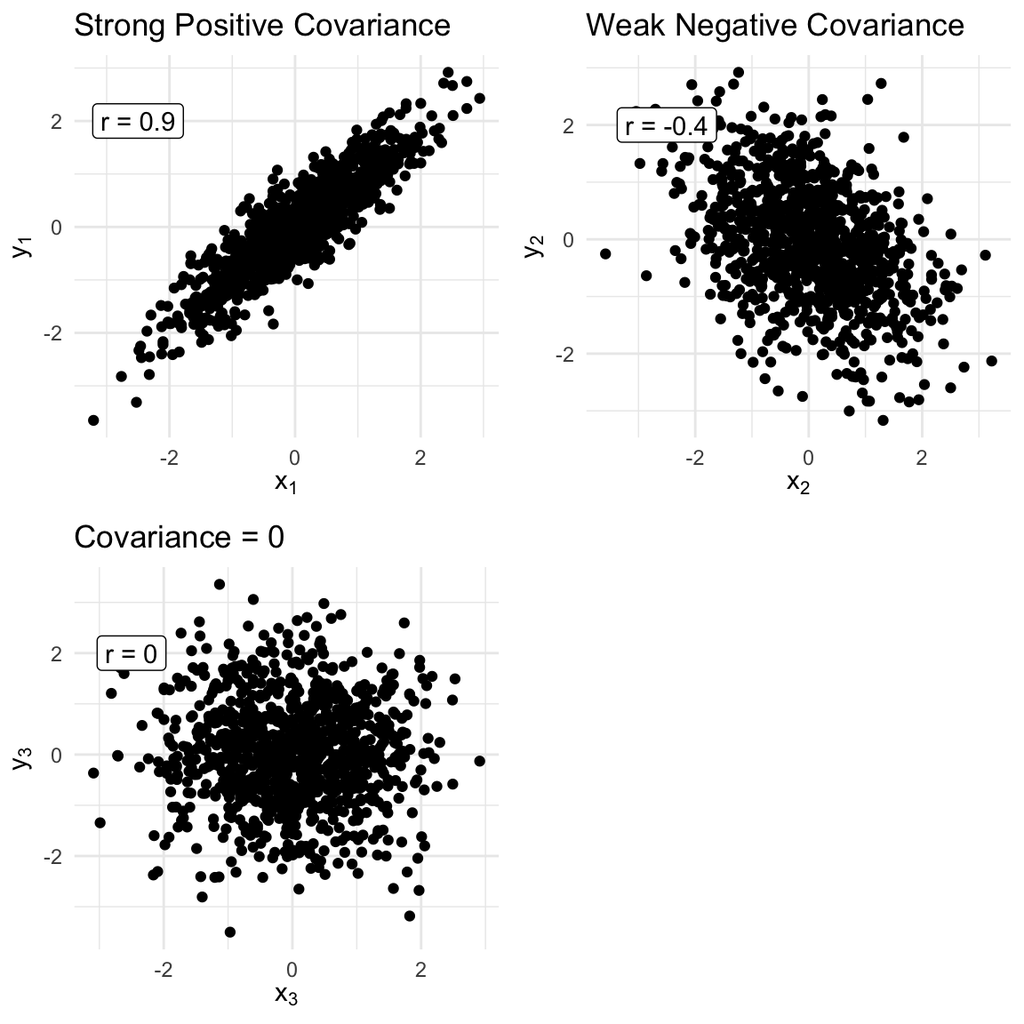

# Correlation significance testing

$H_0$: $r = 0$

$H_A$: two sided ($\rho \ne 0$) or one-sided ($\rho > 0$ or $\rho < 0$)

$r$ has a standard error:

$$s_{r} = \sqrt{\frac{1-r^2}{n-2}}$$
We can then compute a $t$-statistic:

$$t = \frac{r}{s}$$

The probability that $t > \alpha$ (i.e., use the **CDF** of the t distribution) is the p-value.

# Correlation test in R

We can run this test on the penguin example

```r
n = nrow(penguins)
(r = cor(penguins$body_mass_g, penguins$flipper_length_mm))
```

```
## [1] 0.873
```

```r
(s_r = sqrt((1-r^2)/(n-2)))
```

```
## [1] 0.0268
```

```r
(t_val = r/s_r)
```

```
## [1] 32.6
```

```r
(2 * pt(t_val, n-2, lower.tail = FALSE)) # two-sided test
```

```
## [1] 3.13e-105
```

# Correlation test in R

We can run this test on the penguin example

```r
n = nrow(penguins)
(r = cor(penguins$body_mass_g, penguins$flipper_length_mm))
```

```
## [1] 0.873
```

```r
(s_r = sqrt((1-r^2)/(n-2)))
```

```
## [1] 0.0268
```

```r
(t_val = r/s_r)
```

```
## [1] 32.6
```

```r
(2 * pt(t_val, n-2, lower.tail = FALSE)) # two-sided test
```

```
## [1] 3.13e-105
```

And equivalently, using a built-in function

```r
with(penguins,
     cor.test(body_mass_g, flipper_length_mm, alternative = "two.sided"))
```

```
##
##  Pearson's product-moment correlation
##
## data:  body_mass_g and flipper_length_mm
## t = 33, df = 331, p-value <2e-16
## alternative hypothesis: true correlation is not equal to 0
## 95 percent confidence interval:
##  0.845 0.896
## sample estimates:
##   cor
## 0.873
```

# Correlation test: assumptions

- Data must be at least interval scale
  - ordinal data: Spearman rank correlation (avialable in `cor.test` and `cor`)
  - nominal data: Association test (`prop.test`) or $\chi^2$ test (`chisq.test`)
- Population is distributed *bivariate normal* (or $n$ is sufficiently large)

# Correlation pitfalls

- Test is misleading if relationship is nonlinear

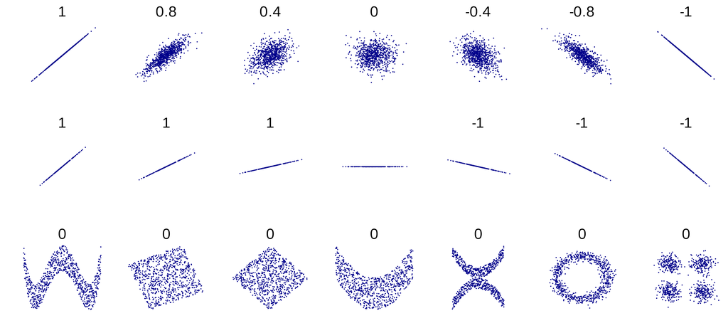

# Correlation pitfalls

Heterogeneity of subgroups

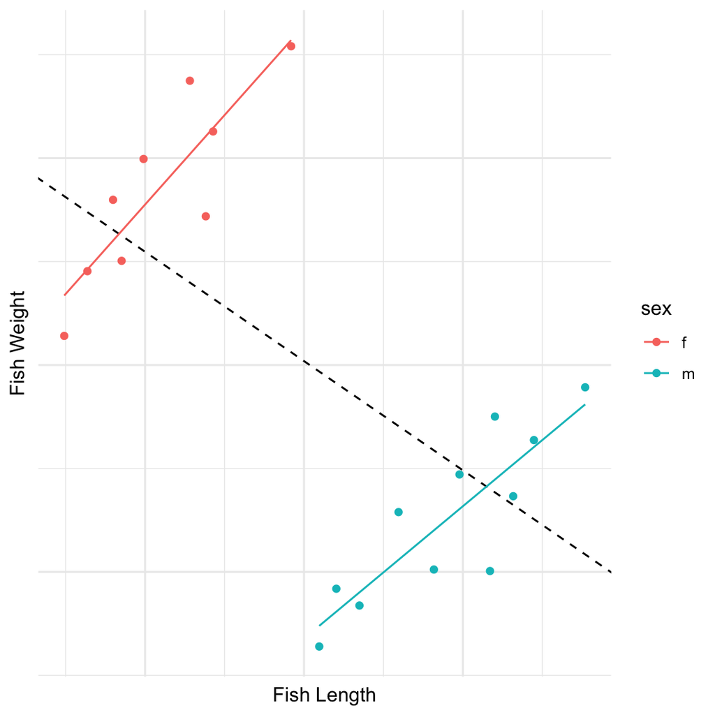

# Spearman correlation

- Used when Pearson correlation assumptions are violated
  - non-normal data
  - non-linear (but monotonic) relationships
  - ordinal data

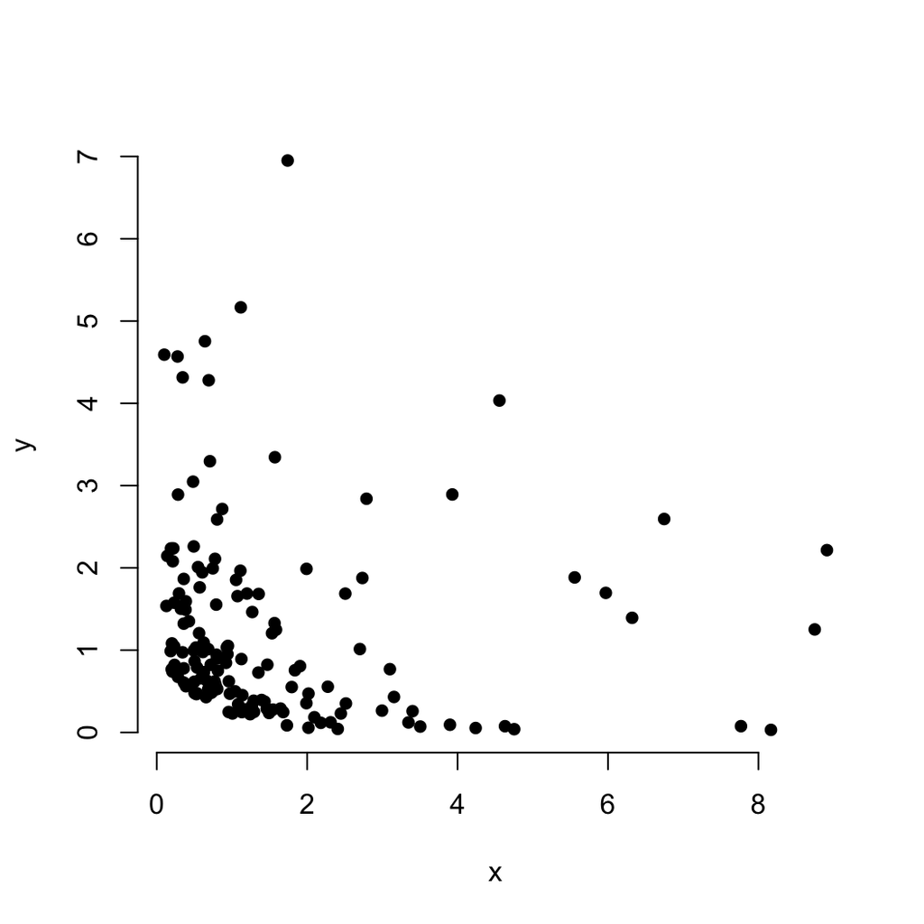

```r
cor.test(x, y)
```

```
##
##  Pearson's product-moment correlation
##
## data:  x and y
## t = -1, df = 148, p-value = 0.3
## alternative hypothesis: true correlation is not equal to 0
## 95 percent confidence interval:
##  -0.2447  0.0734
## sample estimates:
##     cor
## -0.0879
```

# Spearman correlation

- Used when Pearson correlation assumptions are violated
  - non-normal data
  - non-linear (but monotonic) relationships
  - ordinal data

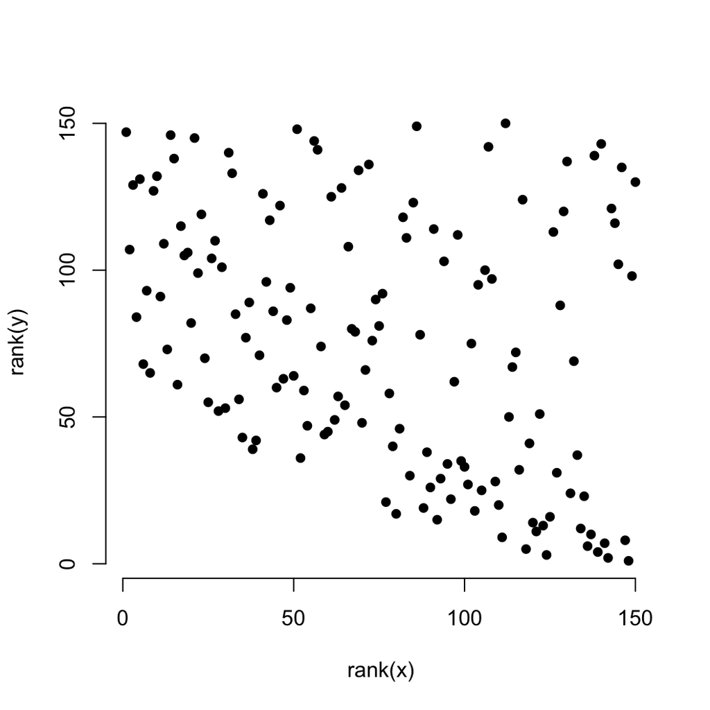

- The math is simple: rank transform x and y, then compute Pearson correlation.

```r
cor.test(x, y)
```

```
##
##  Pearson's product-moment correlation
##
## data:  x and y
## t = -1, df = 148, p-value = 0.3
## alternative hypothesis: true correlation is not equal to 0
## 95 percent confidence interval:
##  -0.2447  0.0734
## sample estimates:
##     cor
## -0.0879
```

```r
cor.test(x, y, method = 'spearman')
```

```
##
##  Spearman's rank correlation rho
##
## data:  x and y
## S = 8e+05, p-value = 9e-06
## alternative hypothesis: true rho is not equal to 0
## sample estimates:
##    rho
## -0.357
```

# Tests of association: 2 × 1 Tables

### Mendel’s peas

- Take homozygous violet (dominant) and white (recessive plants)
- $F_1$ plants are 100% violet
- Theory says that $F_2$ plants should be 75% violet, 25% white

Observation:

| colour | F2 |
| --- | --- |
| violet | 705 |
| white | 224 |

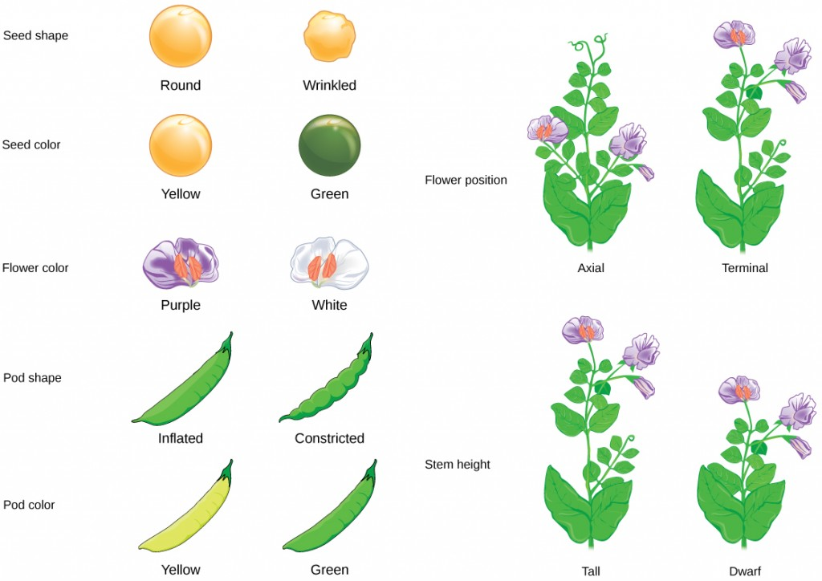

[source](https://opentextbc.ca/biology/chapter/8-1-mendels-experiments/)

# Tests of association: 2 × 1 Tables

### Mendel’s peas

- Take homozygous violet (dominant) and white (recessive plants)
- $F_1$ plants are 100% violet
- Theory says that $F_2$ plants should be 75% violet, 25% white

Observation:

| colour | F2 |
| --- | --- |
| violet | 705 |
| white | 224 |

$H_0$: Inheritance is Mendelian (violet:white = 3:1)

$H_A$: Inheritance is *not* exactly Mendelian

```r
# Test of proportions against a null hypothesis
# For small sample sizes, use binom.test
counts = matrix(c(705, 224), ncol = 2)
prop.test(counts, p = 0.75, alternative = "two.sided")
```

```
##
##  1-sample proportions test with continuity correction
##
## data:  counts, null probability 0.75
## X-squared = 0.3, df = 1, p-value = 0.6
## alternative hypothesis: true p is not equal to 0.75
## 95 percent confidence interval:
##  0.730 0.786
## sample estimates:
##     p
## 0.759
```

# Tests of association: n × n Tables

### Nesting holes of black-backed woodpeckers.

```r
woodpecker = read.csv("../datasets/woodpecker.csv")
head(woodpecker)
```

```
##   forest_type nest_tree
## 1      burned     birch
## 2      burned     birch
## 3      burned jack pine
## 4      burned     aspen
## 5      burned     birch
## 6      burned jack pine
```

```r
table(woodpecker)
```

```
##            nest_tree
## forest_type aspen birch jack pine
##    burned       6    16         2
##    unburned    29    18        23
```

We want to test for an *association* between the two variables (forest type and nest tree)

$H_0$: Nesting tree is not associated with forest type

$H_A$: Nest tree is associated with forest type

# Chi-squared test

### Nesting holes of black-backed woodpeckers.

```r
table(woodpecker)
```

```
##            nest_tree
## forest_type aspen birch jack pine
##    burned       6    16         2
##    unburned    29    18        23
```

```r
table(woodpecker)/rowSums(table(woodpecker))
```

```
##            nest_tree
## forest_type  aspen  birch jack pine
##    burned   0.2500 0.6667    0.0833
##    unburned 0.4143 0.2571    0.3286
```

We can use a $\chi^2$-test to test for this association

$H_0$: Nesting tree is not associated with forest type

$H_A$: Nest tree is associated with forest type

# Chi-squared test

### Nesting holes of black-backed woodpeckers.

```r
table(woodpecker)
```

```
##            nest_tree
## forest_type aspen birch jack pine
##    burned       6    16         2
##    unburned    29    18        23
```

```r
table(woodpecker)/rowSums(table(woodpecker))
```

```
##            nest_tree
## forest_type  aspen  birch jack pine
##    burned   0.2500 0.6667    0.0833
##    unburned 0.4143 0.2571    0.3286
```

We can use a $\chi^2$-test to test for this association

$H_0$: Nesting tree is not associated with forest type

$H_A$: Nest tree is associated with forest type

```r
# for 2x2 tables with small sample sizes: Fisher's exact test
# fisher.test()
with(woodpecker, chisq.test(forest_type, nest_tree))
```

```
##
##  Pearson's Chi-squared test
##
## data:  forest_type and nest_tree
## X-squared = 14, df = 2, p-value = 0.001
```

# Visualisation: Categorical Data

You see this a lot. When should you do it? **NEVER**

- One problem: your brain is bad at converting angles to numbers
- This will over-emphasize large values
- Comparisons among intermediate groups is challenging

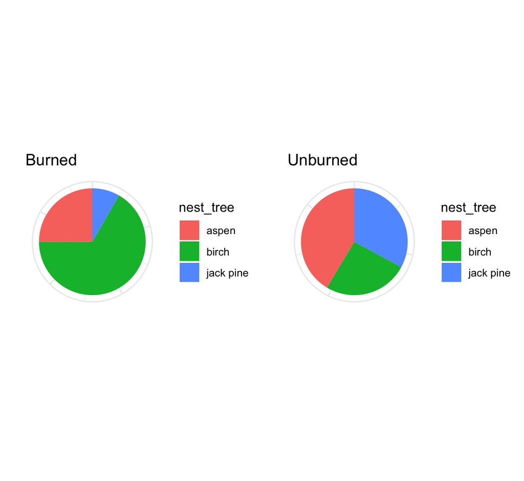

# Visualisation: Categorical Data

This is almost as bad, and sadly much more common

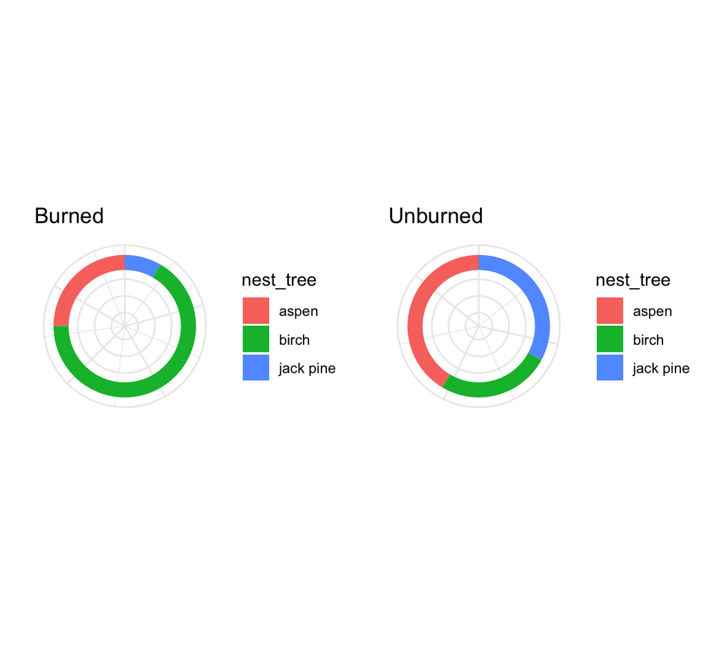

# Visualisation: Categorical Data

Barplots, or proportional bars for counts within categories

```r
table(woodpecker)
```

```
##            nest_tree
## forest_type aspen birch jack pine
##    burned       6    16         2
##    unburned    29    18        23
```

```r
woodp_plot = ggplot(woodpecker, aes(x = nest_tree,
                fill = forest_type)) + theme_minimal()
woodp_plot = woodp_plot + geom_bar(width = 0.5)
woodp_plot
```

Stacked bars are “unfair” — easiest to compare the “rooted” class (unburned).

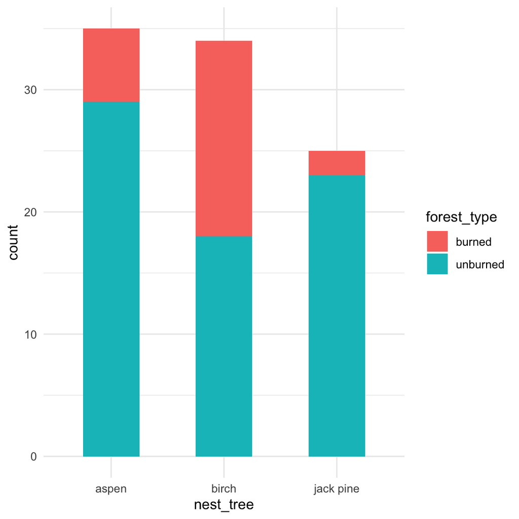

# Visualisation: Categorical Data

Barplots, or proportional bars for counts within categories

```r
table(woodpecker)
```

```
##            nest_tree
## forest_type aspen birch jack pine
##    burned       6    16         2
##    unburned    29    18        23
```

```r
woodp_plot = ggplot(woodpecker, aes(x = nest_tree,
                fill = forest_type))
woodp_plot = woodp_plot + geom_bar(width = 0.5,
                    position=position_dodge())
woodp_plot = woodp_plot + xlab("Nest Tree Type") +
    theme_minimal() + labs(fill = "Forest Type")
woodp_plot
```

Side-by-side bars allow us to compare all categories on equal footing.

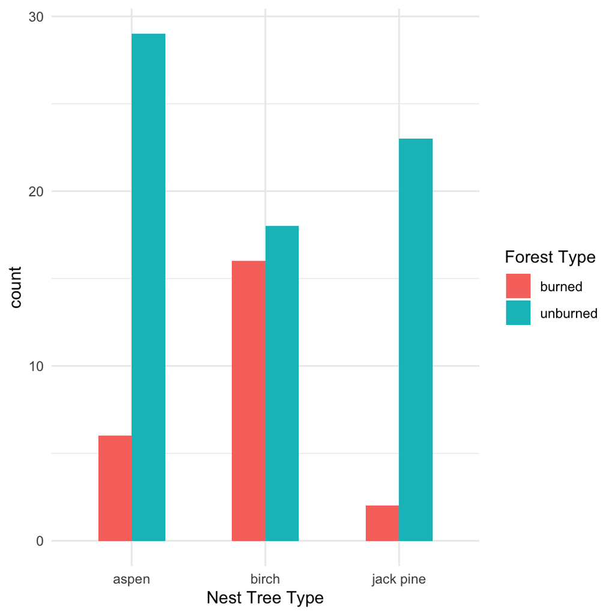

# Visualisation: Ordinal Data

Scatterplots become less useful.

```
##   Grow.degd For.cover  NDVI bird_type richness forest_frag
## 1       330      99.9 60.38    forest        8           1
## 2       330       0.0 22.88    forest        1           0
## 3       330      38.3 11.86    forest        5           3
## 4       330      11.4 19.07    forest        7           7
## 5       330       0.0  2.12    forest        2           0
## 6       170     100.0 54.03    forest        7           1
```

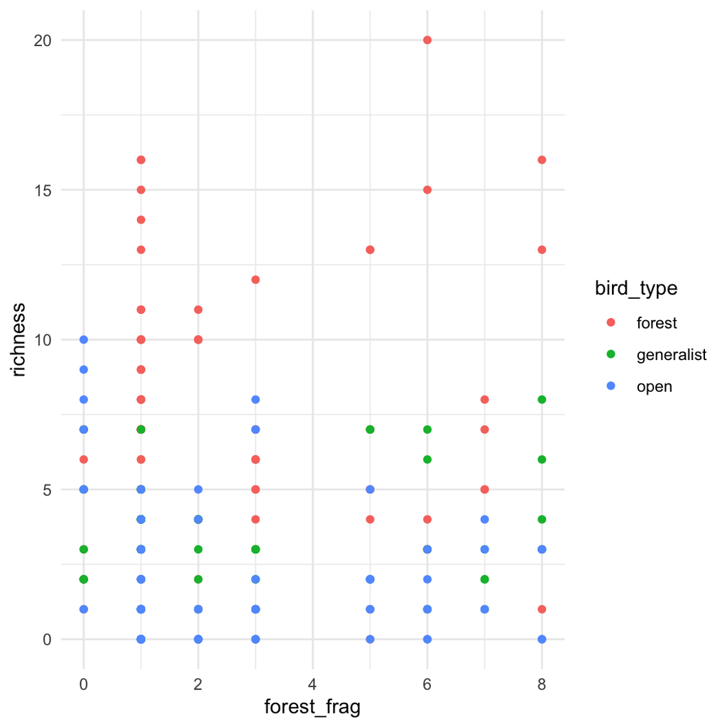

```r
birddiv = read.csv("../datasets/birddiv.csv")
bird_plot = ggplot(birddiv, aes(x=forest_frag,
                y = richness, colour = bird_type)) +
                geom_point() + theme_minimal()
head(birddiv)
```

# Visualisation: Ordinal Data

Adding jitter can sometimes improve things

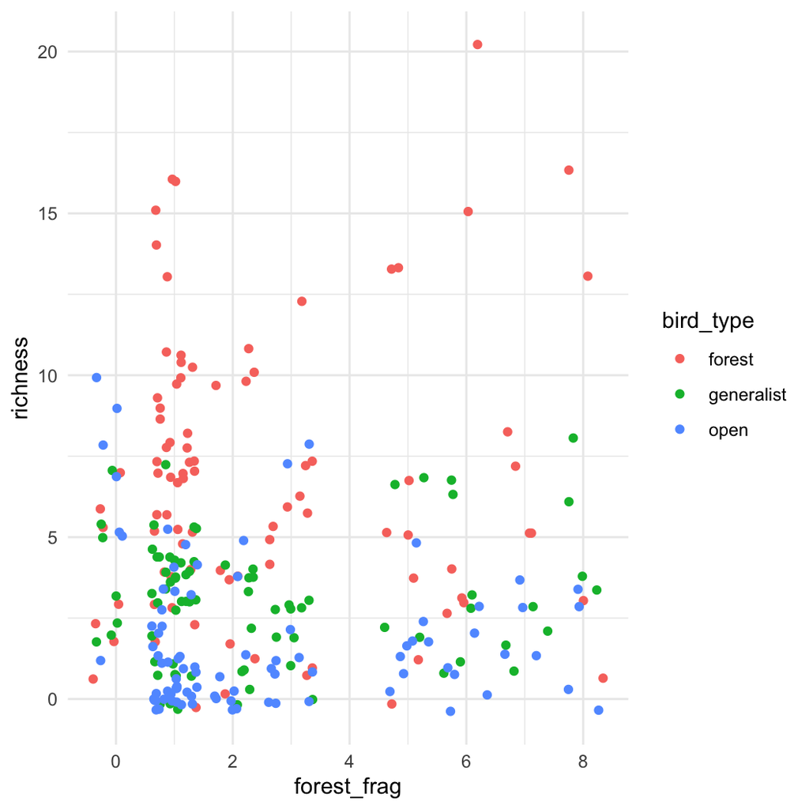

```r
bird_plot = ggplot(birddiv, aes(x=forest_frag,
                y = richness, colour = bird_type)) +
                geom_jitter() + theme_minimal()
```

# Visualisation: Ordinal Data

Another solution: ordered boxplots

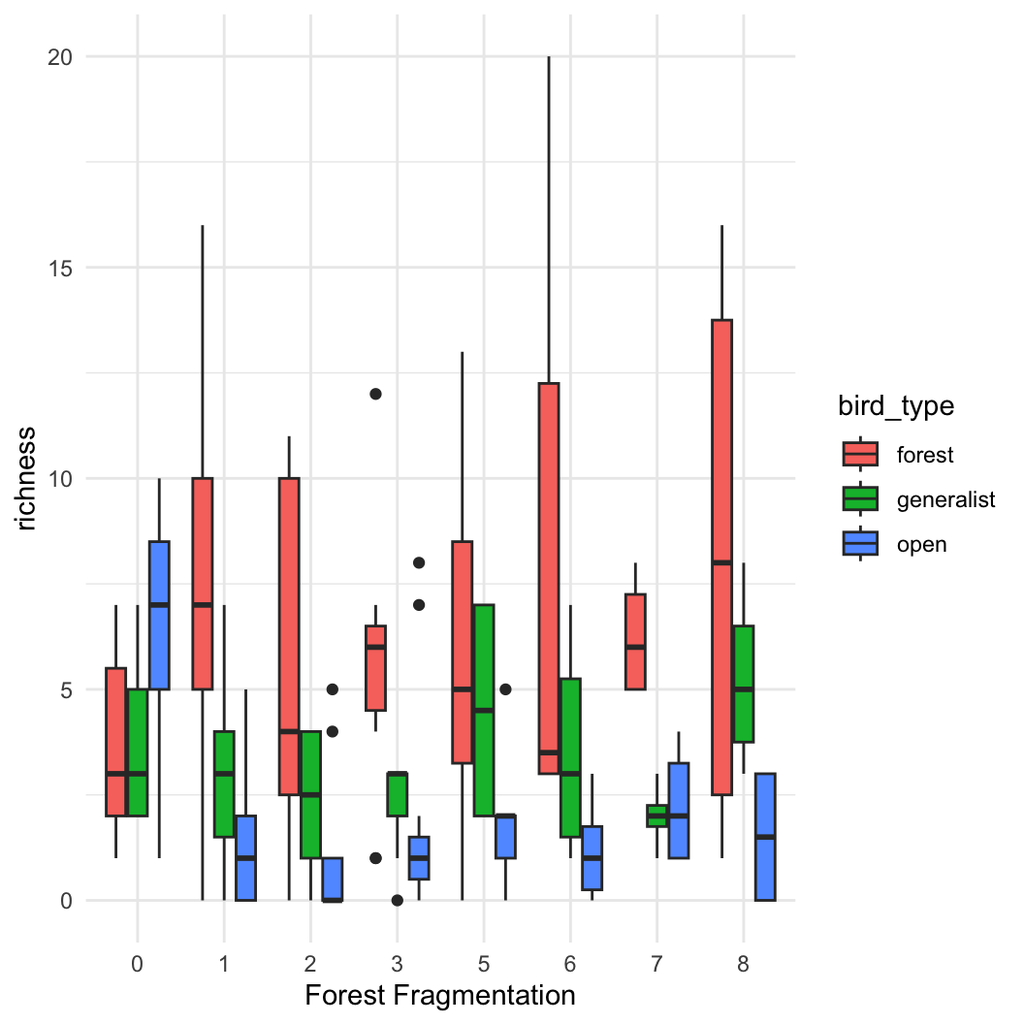

```r
bird_plot = ggplot(birddiv, aes(x=as.factor(forest_frag),
                y = richness, fill = bird_type)) +
                geom_boxplot() + theme_minimal()
bird_plot = bird_plot + xlab("Forest Fragmentation")
```